# UFO Sightings Analysis

## Hypothesis

I predict that there will be a higher frequency of sightings in the central and southern US states. This is for several reasons: first, night sky visibility is better in rural areas, which would increase the likelihood of spotting a UFO. Second, certain areas (e.g. Texas and New Mexico) are known for famous sightings (Lubbock and Roswell, respectively), which may encourage UFO awareness in the region.

## Analysis

The first step was to load in the raw `scrubbed` dataset, as well as the `states` dataset from `maps_data`.

```r
head(scrubbed)
```

```
## # A tibble: 6 x 11
##           datetime                 city state country    shape
##              <chr>                <chr> <chr>   <chr>    <chr>
## 1 10/10/1949 20:30           san marcos    tx      us cylinder
## 2 10/10/1949 21:00         lackland afb    tx    <NA>    light
## 3 10/10/1955 17:00 chester (uk/england)  <NA>      gb   circle
## 4 10/10/1956 21:00                 edna    tx      us   circle
## 5 10/10/1960 20:00              kaneohe    hi      us    light
## 6 10/10/1961 19:00              bristol    tn      us   sphere
## # ... with 6 more variables: `duration (seconds)` <int>, `duration
## #   (hours/min)` <chr>, comments <chr>, `date posted` <chr>,
## #   latitude <dbl>, longitude <dbl>
```

```r
head(states)
```

```
## # A tibble: 6 x 2
##        State Abbreviation
##        <chr>        <chr>
## 1    Alabama           AL
## 2     Alaska           AK
## 3    Arizona           AZ
## 4   Arkansas           AR
## 5 California           CA
## 6   Colorado           CO
```

From the scrubbed data, I filtered to include only the sightings in the US. From this, I then found the frequency of sightings, as grouped by state:

```r
usstate %>% arrange(desc(count))
```

```
## # A tibble: 52 x 2
##    state count
##    <chr> <int>
##  1    ca  8912
##  2    wa  3966
##  3    fl  3835
##  4    tx  3447
##  5    ny  2980
##  6    il  2499
##  7    az  2414
##  8    pa  2366
##  9    oh  2275
## 10    mi  1836
## # ... with 42 more rows
```

I then joined this table with the `state` location data in order to produce a map showing the frequency of sightings per state:

```r
head(mapjoin2)
```

```
## # A tibble: 6 x 8
##        long      lat group order    name subregion state count
##       <dbl>    <dbl> <int> <int>   <chr>     <chr> <chr> <int>
## 1 -87.46201 30.38968     1     1 alabama      <NA>    al   642
## 2 -87.48493 30.37249     1     2 alabama      <NA>    al   642
## 3 -87.52503 30.37249     1     3 alabama      <NA>    al   642
## 4 -87.53076 30.33239     1     4 alabama      <NA>    al   642
## 5 -87.57087 30.32665     1     5 alabama      <NA>    al   642
## 6 -87.58806 30.32665     1     6 alabama      <NA>    al   642
```

## Results

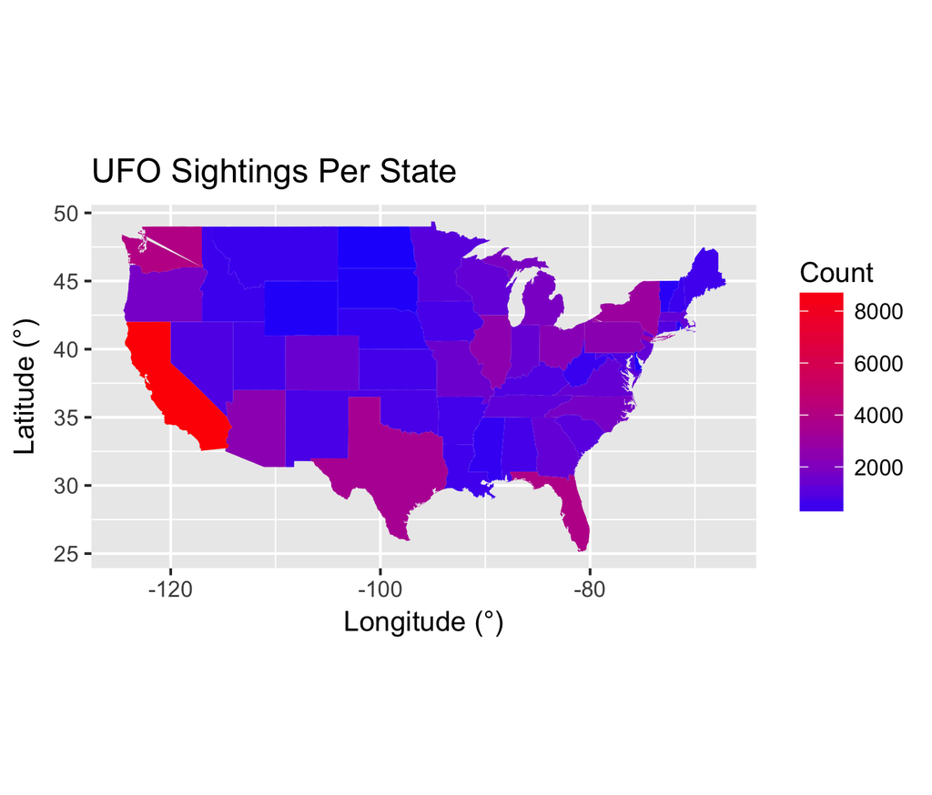

UFO sightings per state